# Our practice project

Author

Mark kuria

This Homework Project works with dataframes in the package `nycflights13` about flights, specifically a sample of domestic flights that departed from the three major New York City airports in 2013.

# 1 Data overview

## 1.1 Package overview

- The data package `nycflights13` package contains five tabular data frames. In total there is information about: - 16 **airlines**
- 1458 **airports**
- 3322 **planes**
- 336776 **flights** The core dataframe `flights` has the following variables: `year`, `month`, `day`: **Date** of departure.  
  `dep_time`, `arr_time`: Actual **departure** and **arrival** times (format HHMM or HMM), local time zone.  
  `sched_dep_time`, `sched_arr_time`: **Scheduled departure** and **arrival** times (format HHMM or HMM), local time zone. `dep_delay`, `arr_delay`: **Departure** and **arrival delays**, in minutes. Negative times represent early departures/arrivals.  
  `carrier`: Two letter **carrier** abbreviation. See `airlines`-dataframe to get the full name.

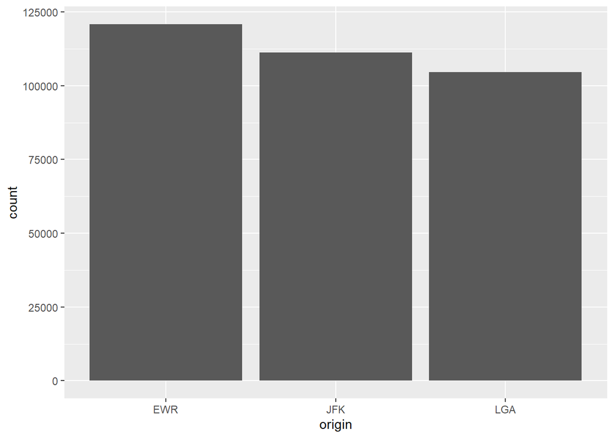

In the `flights` dataframe, the `EWR` airport has **120835** rows, the `JFK` has **111279** rows, and the LGA airport has **104662** rows, resulting in a total of **336776** flights.

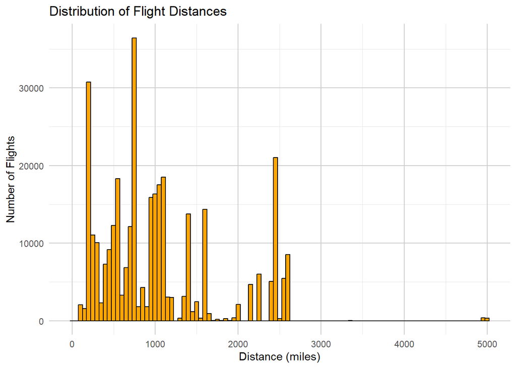

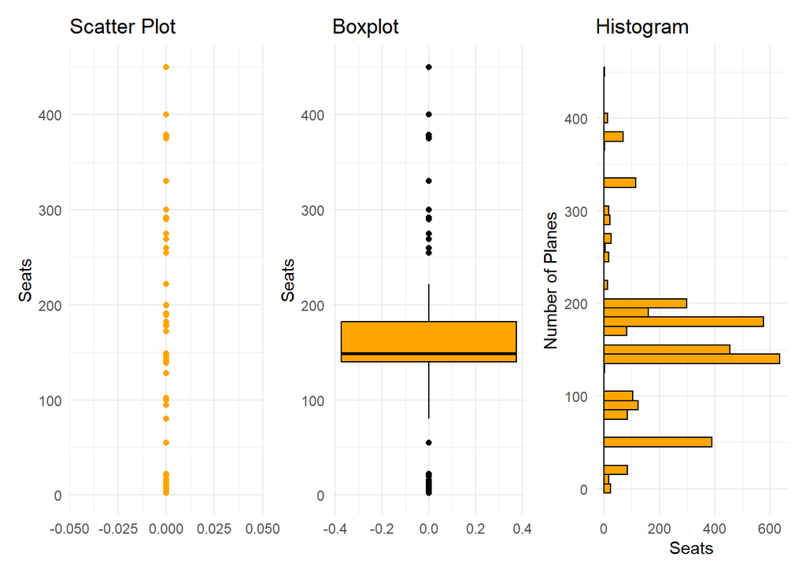

The scatter plot (g1) shows each individual observation of seats in planes.  
The boxplot (g2) summarizes the distribution with median, quartiles, and outliers.  
The histogram (g3) shows the overall frequency distribution of seats. Each visualization has its advantages depending on what we want to see.

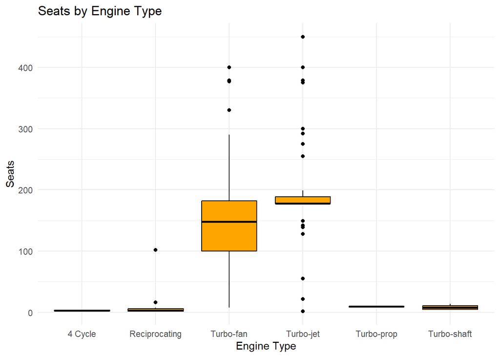

The boxplot shows how the number of seats varies by engine type.  
We can see which engine types typically have more or fewer seats and how spread out the seating capacities are.

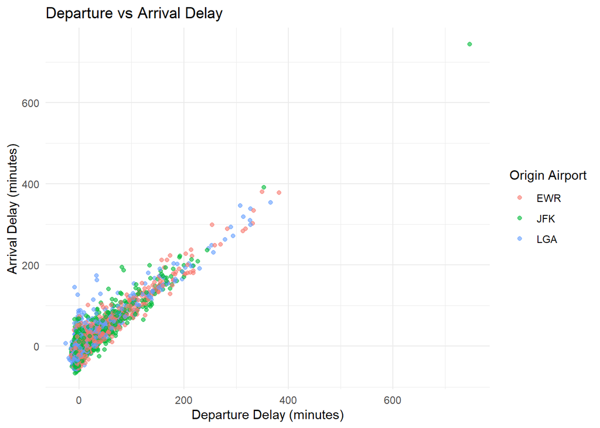

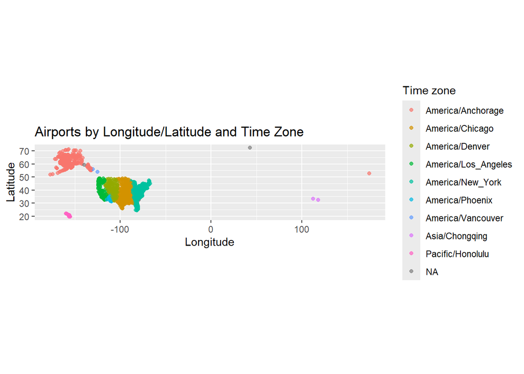

# 2 Data Wrangling

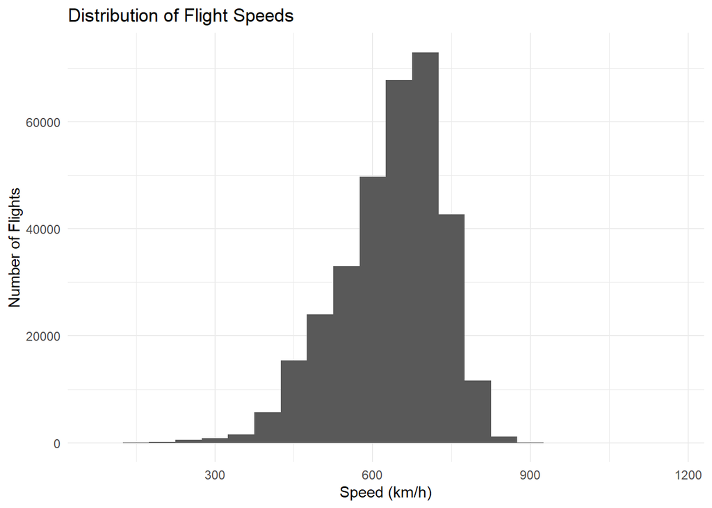

Flights with arrival delay of 2 or more hours

| year | month | day | dep_time | arr_time | carrier | dest | arr_delay |
| --- | --- | --- | --- | --- | --- | --- | --- |
| 2013 | 1 | 1 | 811 | 1047 | MQ | CLT | 137 |
| 2013 | 1 | 1 | 848 | 1001 | MQ | BWI | 851 |
| 2013 | 1 | 1 | 957 | 1056 | UA | BOS | 123 |
| 2013 | 1 | 1 | 1114 | 1447 | UA | IAH | 145 |
| 2013 | 1 | 1 | 1505 | 1638 | EV | RIC | 127 |
| 2013 | 1 | 1 | 1525 | 1831 | B6 | MCO | 125 |
| 2013 | 1 | 1 | 1549 | 1912 | EV | MCI | 136 |
| 2013 | 1 | 1 | 1558 | 1718 | EV | IAD | 123 |
| 2013 | 1 | 1 | 1732 | 2028 | EV | DAY | 123 |
| 2013 | 1 | 1 | 1803 | 2008 | MQ | BNA | 138 |

Average Departure Delay per NYC Airport

| origin | Average Departure Delay (minutes) |
| --- | --- |
| EWR | 15 |
| LGA | 10 |
| JFK | 12 |

# 3 Data Audit

Airports with positive longitude (audit targets)

| faa | name | lat | lon | tzone |
| --- | --- | --- | --- | --- |
| EEN | Dillant Hopkins Airport | 72.27083 | 42.89833 | NA |
| DVT | Deer Valley Municipal Airport | 33.41170 | 112.45700 | Asia/Chongqing |
| MYF | Montgomery Field | 32.47590 | 117.75900 | Asia/Chongqing |
| SYA | Eareckson As | 52.71227 | 174.11362 | America/Anchorage |

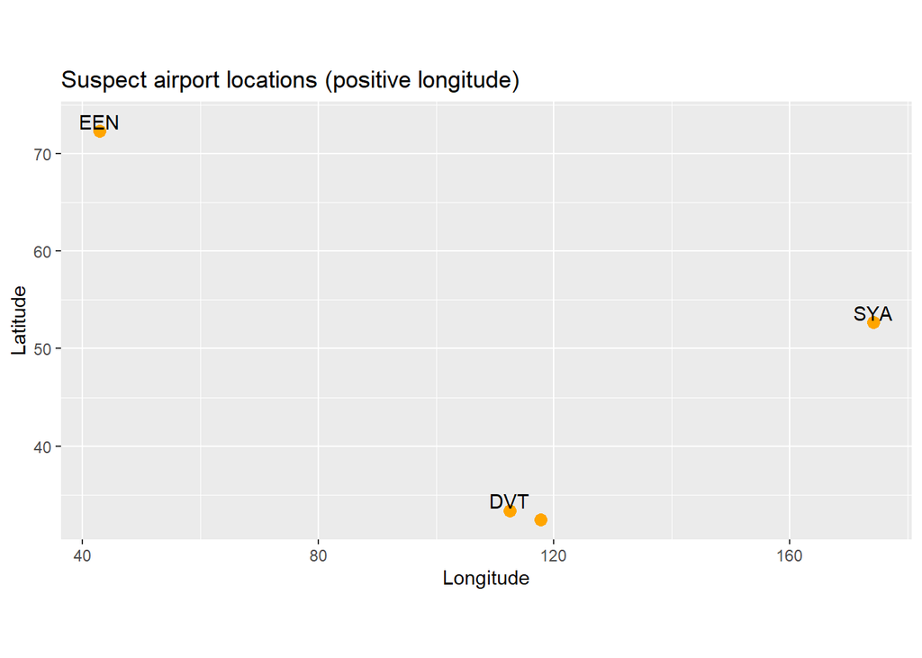

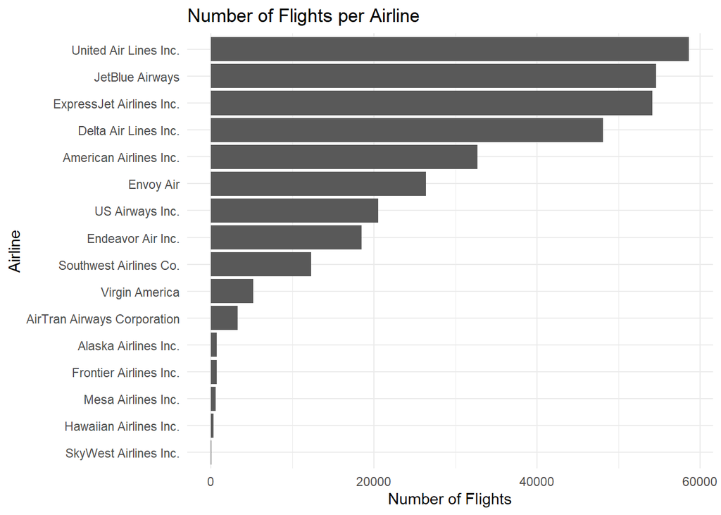

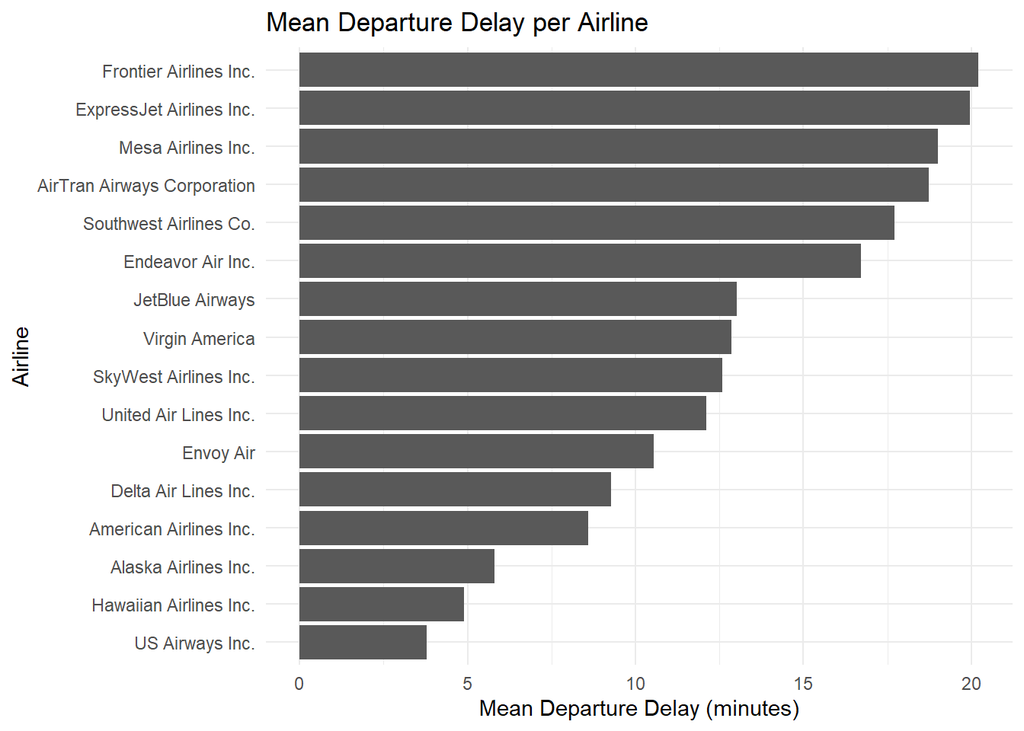

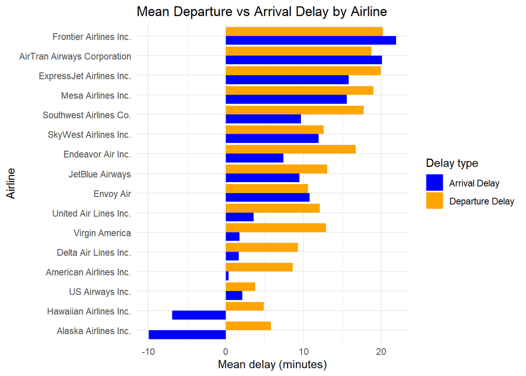

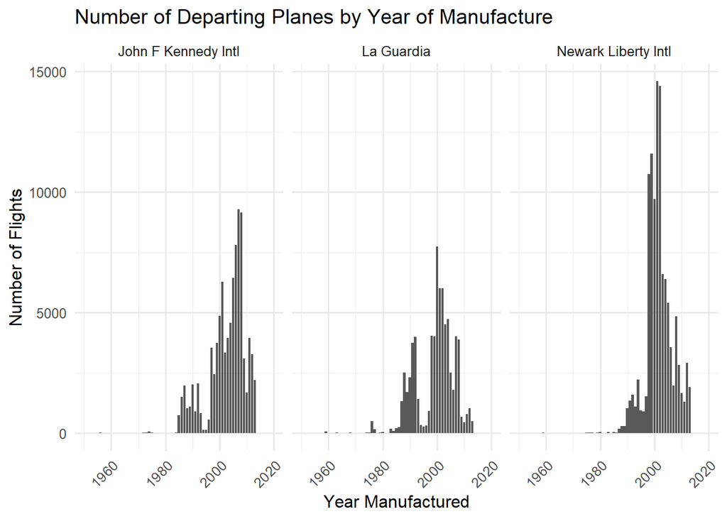

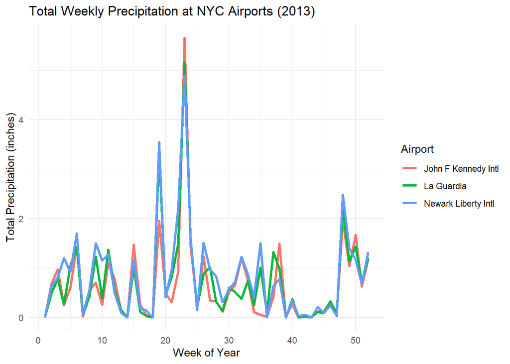

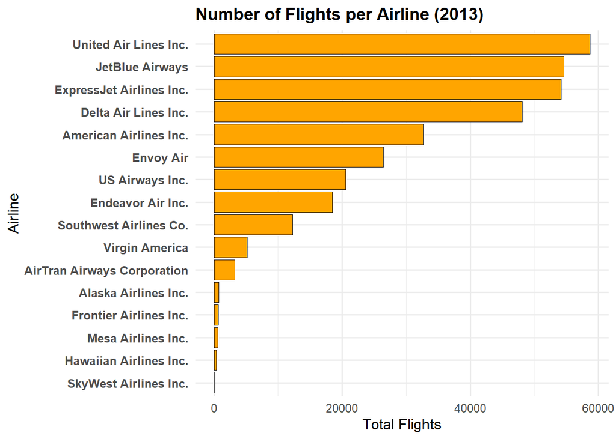

## 7.Do longer flights tend to have more arrival delay?

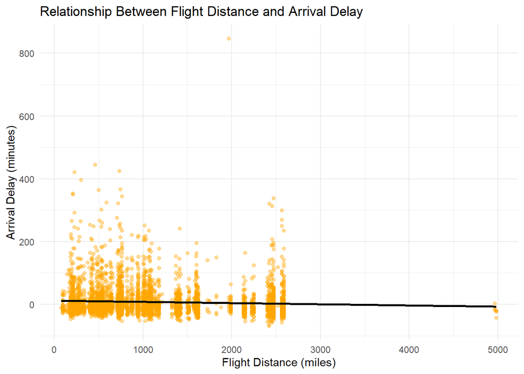